# Ch7 Moving Beyond Linearity

Kiril Raytchev

# *Ex.1*

It was mentioned in the chapter that a cubic regression spline with one knot at $\xi$ can be obtained using a basis of the form $x, x^2, x^3, (x − \xi)_+^3$, where $(x − \xi)_+^3 = (x − \xi)^3$ if $x > \xi$ and equals 0 otherwise.

We will now show that a function of the form

$f(x) = \beta_0 + \beta_1x + \beta_2x^2 + \beta_3x^3 + \beta_4(x − \xi)_+^3$

is indeed a cubic regression spline, regardless of the values of $\beta_0, \beta_1, \beta_2,\beta_3, \beta_4$.

*(a)* Find a cubic polynomial

$f_1(x) = a_1 + b_1x + c_1x^2 + d_1x^3$

such that $f(x) = f_1(x)$ for all $x \le \xi$. Express $a_1, b_1, c_1, d_1$ in terms of $\beta_0, \beta_1, \beta_2,\beta_3, \beta_4$.

*(b)* Find a cubic polynomial

$f_2(x) = a_2 + b_2x + c_2x^2 + d_2x^3$

such that $f(x) = f_2(x)$ for all $x > \xi$. Express $a_2, b_2, c_2, d_2$ in terms of $\beta_0, \beta_1, \beta_2,\beta_3, \beta_4$. We have now established that $f(x)$ is a piecewise polynomial.

> **Answer:** (a) and (b) follows in the picture:

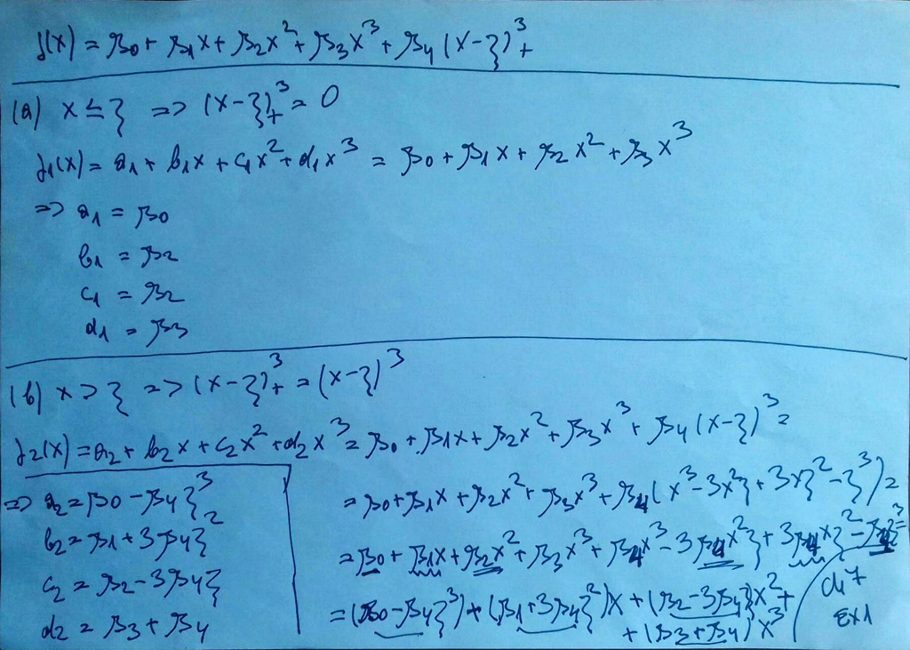

*(c)* Show that $f_1(\xi) = f_2(\xi)$. That is, $f(x)$ is continuous at $\xi$.

*(d)* Show that $f_1'(\xi) = f_2'(\xi)$. That is, $f'(x)$ is continuous at $\xi$.

*(e)* Show that $f_1''(\xi) = f_2''(\xi)$. That is, $f''(x)$ is continuous at $\xi$.

> **Answer:** (c), (d) and (e) follows in the picture:

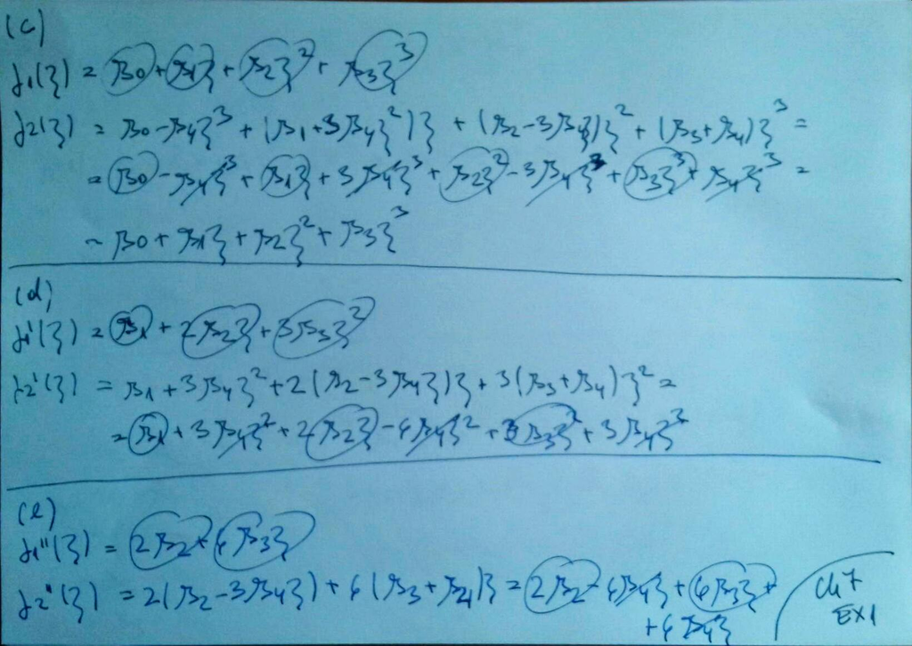

# *Ex.2*

Suppose that a curve $\hat{g}$ is computed to smoothly fit a set of $n$ points using the following formula:

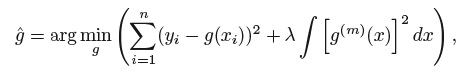

where $g^{(m)}$ represents the $m$th derivative of $g$ (and $g^{(0)} = g$). Provide example sketches of $\hat{g}$ in each of the following scenarios.

*(a)* $\lambda = \infty$, $m = 0$ *(a)* $\lambda = \infty$, $m = 1$ *(a)* $\lambda = \infty$, $m = 2$ *(a)* $\lambda = \infty$, $m = 3$ *(a)* $\lambda = 0$, $m = 3$

> **Answer:** Following are the answers

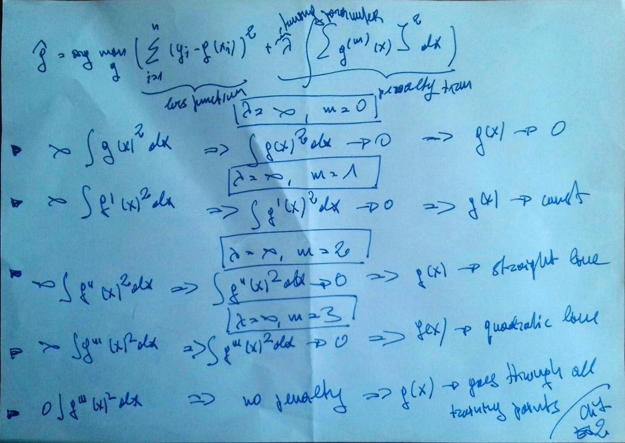

… the and sketches:

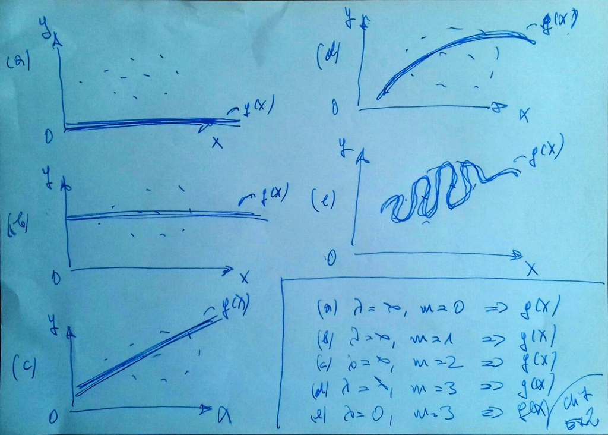

# *Ex.3*

Suppose we fit a curve with basis functions $b_1(X) = X, b_2(X) = (X − 1)^2I(X \ge 1)$. (Note that $I(X \ge 1)$ equals $1$ for $X \ge 1$ and $0$ otherwise.) We fit the linear regression model

$Y = \beta_0 + \beta_1b_1(X) + \beta_2b_2(X) + \epsilon$,

and obtain coefficient estimates $\hat\beta_0 = 1, \hat\beta_1 = 1, \hat\beta_2 = −2$. Sketch the estimated curve between $X = −2$ and $X = 2$. Note the intercepts, slopes, and other relevant information.

> **Answer:** The graph shows that the curve is linear in [-2, 1] and quadratic in [1, 2]

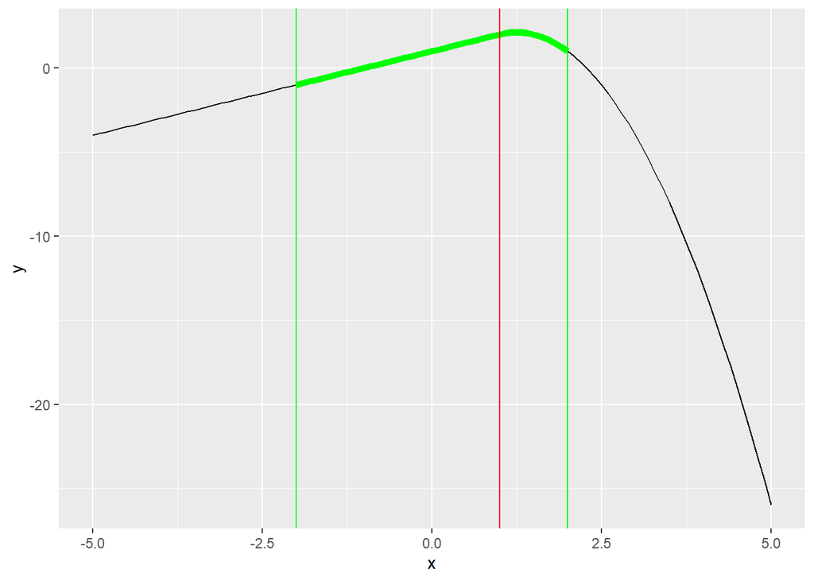

```r
x <- seq(-5, 5, by = 0.1)
y <- 1 + x - 2 * (x - 1)^2 * if_else(x >= 1, 1, 0)

tbl <- tibble(
        x = x,
        y = y
) %>%
        mutate(x_seg = if_else(x <= 2 & x >= -2, x, 0),
               y_seg = 1 + x_seg - 2 * (x_seg - 1)^2 * if_else(x_seg >= 1, 1, 0)
        )

ggplot(tbl) +
        geom_line(aes(x = x, y = y)) +
        geom_line(aes(x = x_seg, y = y_seg), color = "green", size = 2) +
        geom_vline(xintercept = 1, color = "red") +
        geom_vline(xintercept = -2, color = "green") +
        geom_vline(xintercept = 2, color = "green")
```

```r
#clean up and load again kr funcs
#
rm(list = ls())
source("kRfunlib.R")
```

# *Ex.4*

Suppose we fit a curve with basis functions $b_1(X) = I(0 ≤ X ≤ 2) − (X − 1)I(1 ≤ X ≤ 2)$, $b_2(X) = (X − 3)I(3 ≤ X ≤ 4) + I(4 < X ≤ 5)$.

We fit the linear regression model

$Y = β_0 + β_1b_1(X) + β_2b_2(X) + \epsilon$,

and obtain coefficient estimates $\hat\beta_0 = 1, \hat\beta_1 = 1, \hat\beta_2 = 3$.

Sketch the estimated curve between $X = −2$ and $X = 2$. Note the intercepts, slopes, and other relevant information.

> **Answer:** The graph shows that the curve is constant in [-2, 0] and [0, 1], and linear in [1, 2]

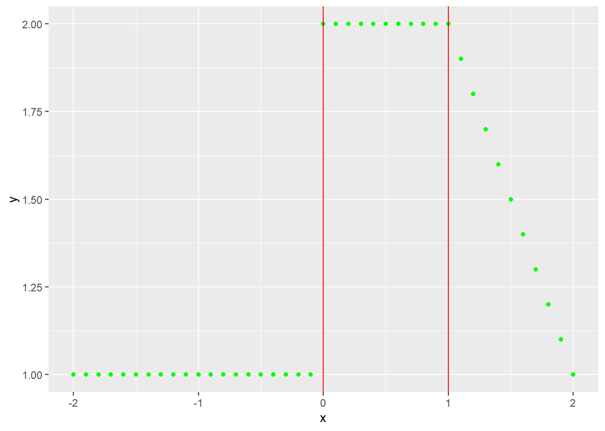

```r
x <- seq(-2, 2, by = 0.1)
y <- 1 +
        1 * if_else((x >= 0 & x <=2), 1, 0) - (x - 1) * if_else((x >= 1 & x <= 2), 1, 0) +
        3 * (x - 3) * if_else((x >= 4 & x <= 4), 1, 0) + if_else((x > 4 & x <= 5), 1, 0)

tbl <- tibble(
        x = x,
        y = y
)

ggplot(tbl) +
        geom_point(aes(x = x, y = y), color = "green") +
        geom_vline(xintercept = 0, color = "red") +
        geom_vline(xintercept = 1, color = "red")
```

```r
#clean up and load again kr funcs
#
rm(list = ls())
source("kRfunlib.R")
```

# *Ex.5*

Consider two curves, $\hat{g_1}$ and $\hat{g_2}$, defined by

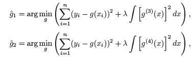

where $g^{(m)}$ represents the m$th$ derivative of g.

*(a)* As $\lambda \rightarrow \infty$, will $\hat{g_1}$ and $\hat{g_2}$ have the smaller training RSS?

> **Answer:** $\hat{g_2}$ has the smaller training RSS, being more flexible in going through the training ponts.

*(b)* As $\lambda \rightarrow \infty$, will $\hat{g_1}$ and $\hat{g_2}$ have the smaller test RSS?

> **Answer:** $\hat{g_1}$ would have lower variance, being less flexible

*(c)* For $\lambda = 0$, will $\hat{g_1}$ and $\hat{g_2}$ have the smaller training and test RSS?

> **Answer:** They would be the same as the penalty term drops out

# *Ex.6*

In this exercise, you will further analyze the `Wage` data set considered throughout this chapter.

*(a)* Perform polynomial regression to predict `wage` using `age`. Use cross-validation to select the optimal degree d for the polynomial.

What degree was chosen, and how does this compare to the results of hypothesis testing using ANOVA?

Make a plot of the resulting polynomial fit to the data.

> **Answer:** As a first step we use cv to select the optimal degree. After that, as step 2, we use ANOVA for the same taks and, in a 3rd step, we compare the results. As a final step we plot the fit.
- Step 1) CV

```r
library(boot)

max_degree <- 5

get_poly_cv_errors <- function(n, ndata){
        glm.fit <- glm(wage ~ poly(age, n), data = ndata)
        cv.error <- cv.glm(ndata, glm.fit)$delta[1]
        tbl <- tibble(
                Degree = n,
                Error =  cv.error,
                Type = as_factor("cv")
        )
        tbl
}

map_df(1:max_degree, get_poly_cv_errors, ndata = Wage)
```

```
## # A tibble: 5 x 3
##   Degree Error Type
##    <int> <dbl> <fct>
## 1      1 1676. cv
## 2      2 1601. cv
## 3      3 1596. cv
## 4      4 1595. cv
## 5      5 1595. cv
```

- Step 2) ANOVA

```r
fit.1 = lm(wage ~ age, data=Wage)
fit.2 = lm(wage ~ poly(age, 2), data=Wage)
fit.3 = lm(wage ~ poly(age, 3), data=Wage)
fit.4 = lm(wage ~ poly(age, 4), data=Wage)
fit.5 = lm(wage ~ poly(age, 5), data=Wage)
anova(fit.1, fit.2, fit.3, fit.4, fit.5)
```

```
## Analysis of Variance Table
##
## Model 1: wage ~ age
## Model 2: wage ~ poly(age, 2)
## Model 3: wage ~ poly(age, 3)
## Model 4: wage ~ poly(age, 4)
## Model 5: wage ~ poly(age, 5)
##   Res.Df     RSS Df Sum of Sq        F    Pr(>F)
## 1   2998 5022216
## 2   2997 4793430  1    228786 143.5931 < 2.2e-16 ***
## 3   2996 4777674  1     15756   9.8888  0.001679 **
## 4   2995 4771604  1      6070   3.8098  0.051046 .
## 5   2994 4770322  1      1283   0.8050  0.369682
## ---
## Signif. codes:  0 '***' 0.001 '**' 0.01 '*' 0.05 '.' 0.1 ' ' 1
```

- Step 4) Plotting the Fit

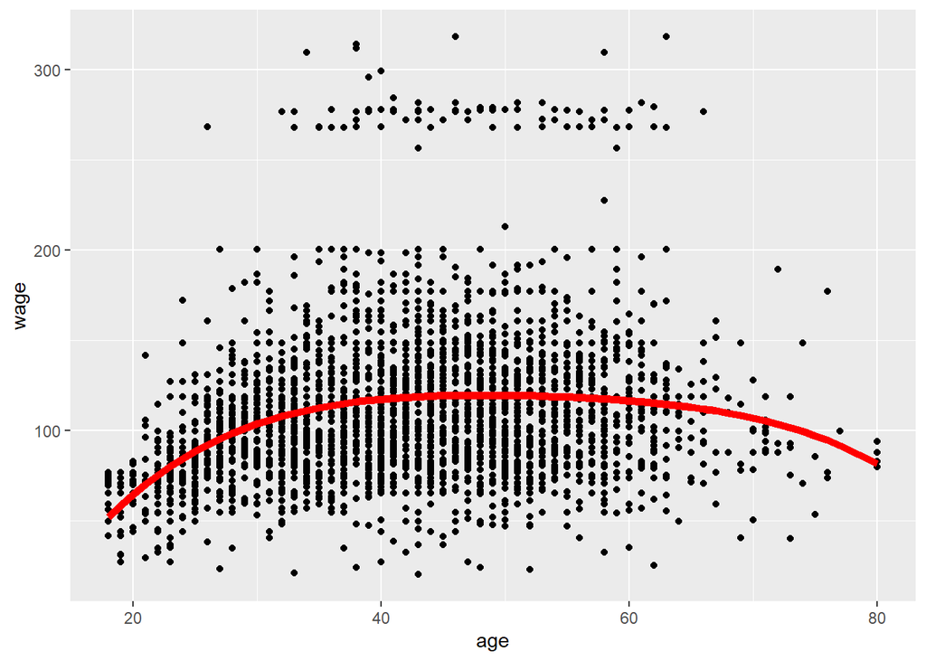

```r
Wage_augm <- augment(fit.4, data = Wage)

ggplot(Wage_augm) +
        geom_point(aes(x = age, y = wage)) +
        geom_line(aes(x = age, y = .fitted), color = "red", size = 2)
```

```r
#clean up and load again kr funcs
#
rm(list = ls())
source("kRfunlib.R")
```

*(b)* Fit a step function to predict `wage` using `age`, and perform crossvalidation to choose the optimal number of cuts. Make a plot of the fit obtained.

```r
library(boot)

max_cut <- 10

get_step_cv_errors <- function(n, ndata, var){
        ndata$cut_var <- cut(var, n)
        glm.fit <- glm(wage ~ cut_var, data = ndata)
        cv.error <- cv.glm(ndata, glm.fit)$delta[1]
        tbl <- tibble(
                Cuts = n,
                Error =  cv.error,
                Type = as_factor("cv")
        )
        tbl
}

map_df(2:max_cut, get_step_cv_errors, ndata = Wage, var = Wage$age)
```

```
## # A tibble: 9 x 3
##    Cuts Error Type
##   <int> <dbl> <fct>
## 1     2 1734. cv
## 2     3 1683. cv
## 3     4 1636. cv
## 4     5 1631. cv
## 5     6 1623. cv
## 6     7 1612. cv
## 7     8 1601. cv
## 8     9 1610. cv
## 9    10 1605. cv
```

We observer min cv error at `max_cut = 8`

Following is the plot of the selected fit:

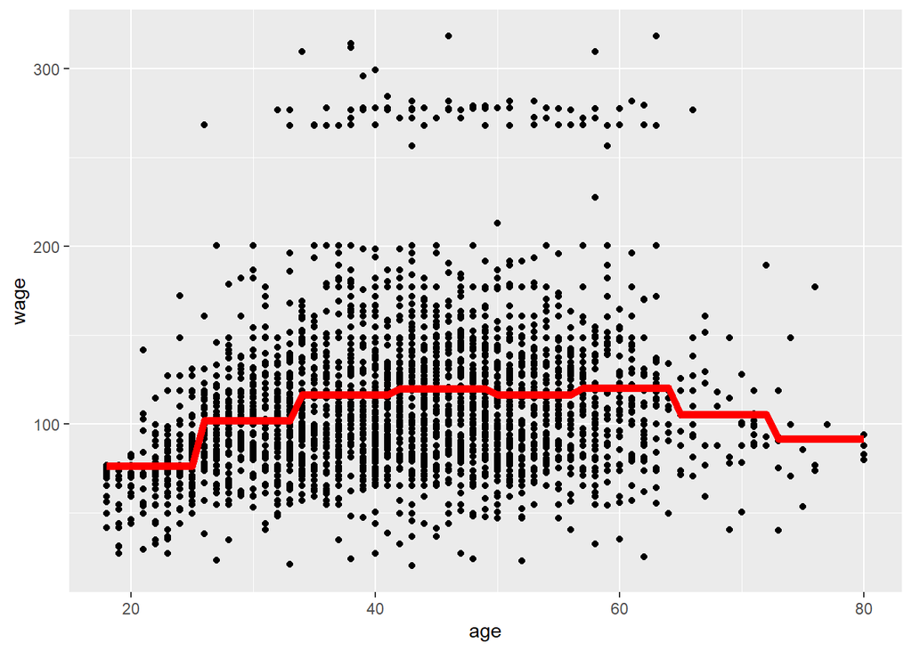

```r
Wage$cut_var <- cut(Wage$age, 8)

glm.fit <- glm(wage ~ cut_var, data = Wage)

Wage_augm <- augment(glm.fit, data = Wage)

ggplot(Wage_augm) +
        geom_point(aes(x = age, y = wage)) +
        geom_line(aes(x = age, y = .fitted), color = "red", size = 2)
```

```r
#clean up and load again kr funcs
#
rm(list = ls())
source("kRfunlib.R")
```

# *Ex.7*

The `Wage` data set contains a number of other features not explored in this chapter, such as marital status (`maritl`), job class (`jobclass`), and others. Explore the relationships between some of these other predictors and `wage`, and use non-linear fitting techniques in order to fit flexible models to the data.

Create plots of the results obtained, and write a summary of your findings.

```r
library(corrr)

# Wage %>%
#         correlate() %>%
#         focus(wage)
```

```r
#clean up and load again kr funcs
#
rm(list = ls())
source("kRfunlib.R")
```